# Stress test

The four-channel loss-of-flow case was run 94 times around its operating point, one parameter at a time. Each case is a fresh build, a toolkit guess, a steady solve, a scram and a 2500 s transient, all in its own process.

Completed means the case reached 2500 s. Saturation means the bulk coolant reached saturation and STREAM stopped with a `SaturationReachedError` naming the channel and cell: the single-phase model's stated validity boundary. Failed means the solver gave up; timeout, that the case overran its time limit.

The cells read the stored tables in `results/`; with `RECOMPUTE = True` each axis re-runs through `sweeps.run_axis` first.

```python
%matplotlib inline
import sys
from pathlib import Path

import matplotlib.pyplot as plt
import numpy as np
import pandas as pd
from matplotlib.lines import Line2D

sys.path.insert(0, str(Path.cwd().parent))
from showcase import plots, sweeps
from showcase.lofa_case import HEATED, TSAT

RECOMPUTE = False
COLUMNS = ["label", "status", "t_open", "t_rev_hot", "t_rev_warm", "t_rev_wide", "peak_hot", "margin",
           "n_warnings", "wall_s"]
FORMATS = dict(t_open="{:.1f}", t_rev_hot="{:.0f}", t_rev_warm="{:.0f}", t_rev_wide="{:.0f}", peak_hot="{:.1f}",
               margin="{:.1f}", wall_s="{:.0f}", residual_entry="{:.3g}")
frames = {}


def load(axis):
    if axis not in frames:
        frames[axis] = sweeps.run_axis(axis) if RECOMPUTE else sweeps.load(axis)
    return frames[axis]


def table(df, columns=COLUMNS):
    formats = {k: v for k, v in FORMATS.items() if k in columns}
    return df[columns].style.format(formats, na_rep="").hide(axis="index")
```

```python
MARK = dict(
    completed=lambda c: dict(marker="o", color=c),
    saturation=lambda c: dict(marker="o", color=c, markerfacecolor="white",
                              markeredgecolor=plots.STATUS_COLORS["saturation"], markeredgewidth=2),
    failed=lambda c: dict(marker="X", color=plots.STATUS_COLORS["failed"]),
    timeout=lambda c: dict(marker="s", color=plots.STATUS_COLORS["timeout"]),
)


def series(ax, xs, ys, status, color, label=None):
    ax.plot(xs, ys, color=color, label=label)
    for s, kw in MARK.items():
        m = (status == s).to_numpy()
        ax.plot(xs[m], ys[m], linestyle="none", **kw(color))


def saturation(ax, xs, df):
    tsat = np.array([TSAT(p) for p in df["p_p_ref"]])
    if np.ptp(tsat) == 0:
        plots.hline(ax, tsat[0], f"Saturation {tsat[0]:.1f} °C")
        return
    ax.plot(xs, tsat, "--", color=plots.NEUTRAL, linewidth=1.5)
    ax.annotate("Saturation", xy=(xs[-1], tsat[-1]), xytext=(-4, -14), textcoords="offset points", ha="right",
                color=plots.NEUTRAL)
```

```python
def figure(df, x, xlabel, logx=False, scale=1.0):
    categorical = x == "label"
    df = df if categorical else df.sort_values(x)
    xs = np.arange(len(df)) if categorical else df[x].to_numpy(float) * scale
    fig, axes = plt.subplots(1, 3, figsize=(12, 3.8), layout="constrained")
    for k in HEATED:
        series(axes[0], xs, df[f"t_rev_{k}"].to_numpy(), df["status"], plots.COLORS[k])
        series(axes[1], xs, df[f"peak_{k}"].to_numpy(), df["status"], plots.COLORS[k])
    series(axes[2], xs, df["t_open"].to_numpy(), df["status"], plots.INK)
    saturation(axes[1], xs, df)
    for ax, ylabel in zip(axes, ("Flow reversal [s]", "Peak coolant temperature [°C]", "Flapper opening [s]")):
        ax.set_xlabel(xlabel)
        ax.set_ylabel(ylabel)
        if logx:
            ax.set_xscale("log")
        if categorical:
            ax.set_xticks(xs, df["label"], rotation=30, ha="right")
    finish(fig, axes, df)
    return fig
```

```python
def finish(fig, axes, df):
    opening = df["t_open"].dropna()
    if np.ptp(opening) < 8:
        mid = 0.5 * (opening.max() + opening.min())
        axes[2].set_ylim(mid - 4, mid + 4)
    present = [s for s in MARK if (df["status"] == s).any()]
    handles = [Line2D([], [], color=plots.COLORS[k]) for k in HEATED]
    handles += [Line2D([], [], linestyle="none", **MARK[s](plots.NEUTRAL)) for s in present]
    labels = [k.capitalize() for k in HEATED] + [s.capitalize() for s in present]
    fig.legend(handles, labels, loc="outside upper center", ncol=len(labels))


def show(axis, x, xlabel, logx=False, scale=1.0, rows=None):
    df = load(axis)
    df = df[rows(df)] if rows is not None else df
    with plots.style():
        figure(df, x, xlabel, logx, scale)
        plt.show()
    return table(df)
```

## Where runs stopped

Every run that ended early, with the time it stopped and what its error names. The stop times quoted below come from this table.

```python
PATTERN = r"Channel '(?P<channel>\w+)'.*?worst cell (?P<cell>\d+): T_bulk=(?P<t_bulk>[\d.]+)°C >= Tsat=(?P<tsat>[\d.]+)°C"
runs = pd.concat([load(axis) for axis in sweeps.AXES], ignore_index=True)
stops = runs[runs["status"] != "completed"]
stops = stops[["axis", "label", "status", "t_last"]].join(stops["error"].str.extract(PATTERN))
stops.style.format({"t_last": "{:.0f}"}, na_rep="").hide(axis="index")
```

| axis | label | status | t_last | channel | cell | t_bulk | tsat |
| --- | --- | --- | --- | --- | --- | --- | --- |
| power | power_scale=0.95 | saturation | 2461 | HotChannel | 1 | 120.50 | 120.50 |
| power | power_scale=1.0 | saturation | 2413 | HotChannel | 1 | 120.50 | 120.50 |
| inertia | inertia=0.3 | saturation | 805 | HotChannel | 1 | 120.50 | 120.50 |
| inertia | inertia=0.5 | saturation | 1346 | HotChannel | 1 | 120.50 | 120.50 |
| gaps | hot=1.5mm | saturation | 658 | HotChannel | 6 | 121.03 | 121.03 |
| gaps | bypass=3mm | saturation | 2367 | HotChannel | 1 | 120.50 | 120.50 |
| flapper_threshold | flapper_fraction=0.1 | saturation | 2146 | HotChannel | 1 | 120.50 | 120.50 |
| flapper_area | flapper_area=0.3 | saturation | 1420 | HotChannel | 1 | 120.50 | 120.50 |
| tolerance | atol=0.1,rtol=0.001 | failed | 286 |  |  |  |  |

## Power

Power runs from 0.30 to 1.00 of full; 0.70 is the operating point. The margin falls from 32.2 °C to 5.1 °C at 0.90 and crosses zero before 0.95, where both top rungs stop on saturation in the hot channel. More power brings every reversal earlier.

Saturated points sit about 0.2 °C above the line: the stop uses the pressure in the cell, a little above the reference pressure the line is drawn at.

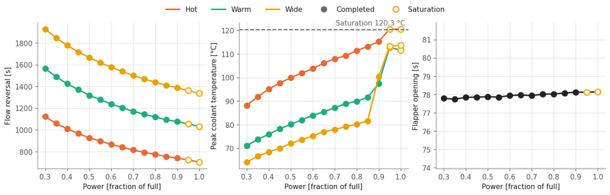

| label | status | t_open | t_rev_hot | t_rev_warm | t_rev_wide | peak_hot | margin | n_warnings | wall_s |
| --- | --- | --- | --- | --- | --- | --- | --- | --- | --- |
| power_scale=0.3 | completed | 77.8 | 1122 | 1564 | 1928 | 88.1 | 32.2 | 0 | 51 |
| power_scale=0.35 | completed | 77.7 | 1058 | 1488 | 1846 | 91.9 | 28.4 | 0 | 52 |
| power_scale=0.4 | completed | 77.8 | 1010 | 1424 | 1778 | 95.1 | 25.2 | 0 | 54 |
| power_scale=0.45 | completed | 77.9 | 966 | 1370 | 1718 | 97.6 | 22.7 | 0 | 52 |
| power_scale=0.5 | completed | 77.9 | 926 | 1318 | 1666 | 99.9 | 20.4 | 0 | 53 |
| power_scale=0.55 | completed | 77.9 | 898 | 1278 | 1620 | 101.8 | 18.4 | 0 | 50 |
| power_scale=0.6 | completed | 77.9 | 866 | 1238 | 1576 | 103.7 | 16.6 | 0 | 53 |
| power_scale=0.65 | completed | 78.0 | 840 | 1204 | 1538 | 106.1 | 14.2 | 0 | 53 |
| power_scale=0.7 | completed | 77.9 | 814 | 1170 | 1500 | 107.9 | 12.4 | 0 | 52 |
| power_scale=0.75 | completed | 78.0 | 792 | 1144 | 1468 | 109.2 | 11.1 | 0 | 55 |
| power_scale=0.8 | completed | 78.0 | 774 | 1118 | 1438 | 111.3 | 9.0 | 0 | 55 |
| power_scale=0.85 | completed | 78.1 | 754 | 1092 | 1410 | 113.1 | 7.2 | 0 | 53 |
| power_scale=0.9 | completed | 78.1 | 740 | 1076 | 1388 | 115.2 | 5.1 | 0 | 59 |
| power_scale=0.95 | saturation | 78.1 | 722 | 1054 | 1362 | 120.5 | -0.2 | 0 | 60 |
| power_scale=1.0 | saturation | 78.1 | 704 | 1032 | 1336 | 120.5 | -0.2 | 0 | 35 |

```python
show("power", "p_power_scale", "Power [fraction of full]")
```

## Pump head

A stronger pump opens the flapper sooner (98 s at half head, 62 s at double) and delays the reversals. The peak barely moves. The flapper set point is 30 % of a nominal flow estimated from the pump head and the channel gaps, so along this axis the set point rises with the head.

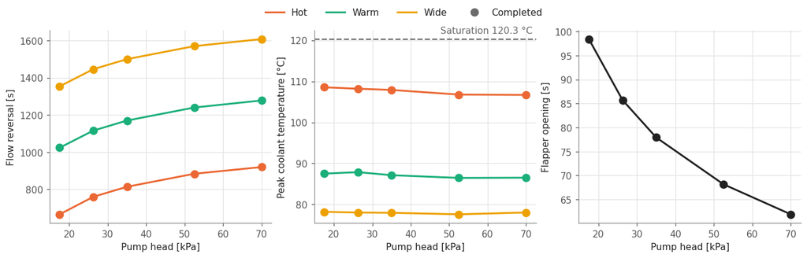

| label | status | t_open | t_rev_hot | t_rev_warm | t_rev_wide | peak_hot | margin | n_warnings | wall_s |
| --- | --- | --- | --- | --- | --- | --- | --- | --- | --- |
| pump_head=0.5 | completed | 98.5 | 666 | 1024 | 1354 | 108.5 | 11.8 | 0 | 30 |
| pump_head=0.75 | completed | 85.7 | 760 | 1116 | 1446 | 108.2 | 12.1 | 0 | 29 |
| pump_head=1.0 | completed | 77.9 | 814 | 1170 | 1500 | 107.9 | 12.4 | 0 | 32 |
| pump_head=1.5 | completed | 68.2 | 884 | 1240 | 1570 | 106.8 | 13.5 | 0 | 34 |
| pump_head=2.0 | completed | 61.9 | 920 | 1278 | 1608 | 106.7 | 13.6 | 0 | 36 |

```python
show("pump_head", "p_pump_head", "Pump head [kPa]", scale=1e-3)
```

## Flywheel inertia

A short coastdown reverses the channels while decay heat is still high: at 0.3 and 0.5 times the default inertia the hot channel saturates, at about 805 s and 1346 s (stops table). At 2 and 3 times some or all reversals fall past the 2500 s window. Those runs complete; the missing points are reversals that had not happened yet.

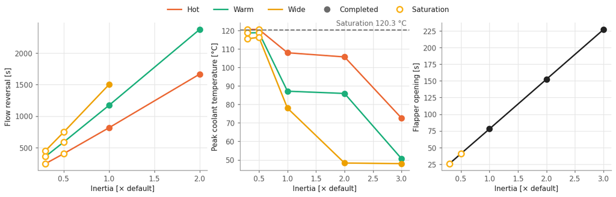

| label | status | t_open | t_rev_hot | t_rev_warm | t_rev_wide | peak_hot | margin | n_warnings | wall_s |
| --- | --- | --- | --- | --- | --- | --- | --- | --- | --- |
| inertia=0.3 | saturation | 25.9 | 244 | 358 | 450 | 120.5 | -0.2 | 0 | 38 |
| inertia=0.5 | saturation | 40.8 | 402 | 586 | 744 | 120.5 | -0.2 | 0 | 38 |
| inertia=1.0 | completed | 77.9 | 814 | 1170 | 1500 | 107.9 | 12.4 | 0 | 35 |
| inertia=2.0 | completed | 152.6 | 1666 | 2376 |  | 105.7 | 14.6 | 0 | 32 |
| inertia=3.0 | completed | 227.2 |  |  |  | 72.5 | 47.8 | 0 | 28 |

```python
show("inertia", "p_inertia", "Inertia [× default]", scale=1 / 3e5)
```

## Channel gaps

One gap changes per case. A 1.5 mm hot gap has a quarter less flow area at the same power and saturates at the reversal spike, about 658 s (stops table), before the other channels have warmed. A 3 mm bypass, against 4 mm, weakens natural circulation, and the hot channel creeps to saturation at about 2367 s (stops table). The flapper set point is 30 % of a nominal flow estimated from the pump head and the gaps, so it moves with the gaps too; the opening runs from about 43 s to 167 s across these cases.

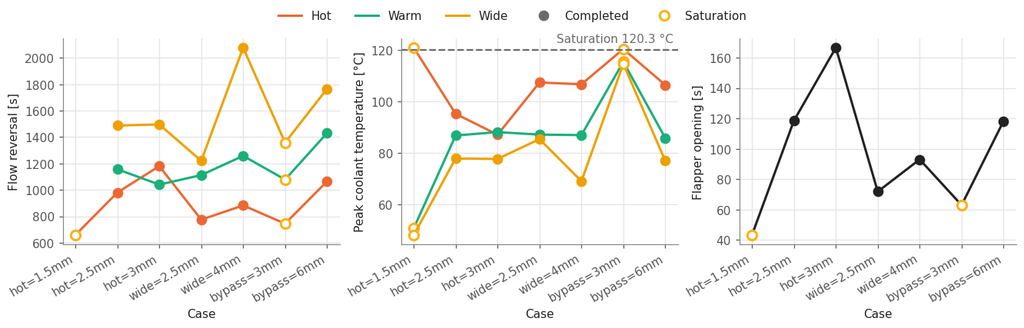

| label | status | t_open | t_rev_hot | t_rev_warm | t_rev_wide | peak_hot | margin | n_warnings | wall_s |
| --- | --- | --- | --- | --- | --- | --- | --- | --- | --- |
| hot=1.5mm | saturation | 43.3 | 658 |  |  | 121.0 | -0.7 | 0 | 41 |
| hot=2.5mm | completed | 118.6 | 980 | 1156 | 1488 | 95.2 | 25.1 | 0 | 38 |
| hot=3mm | completed | 166.6 | 1180 | 1040 | 1496 | 87.1 | 32.2 | 0 | 33 |
| wide=2.5mm | completed | 71.9 | 774 | 1112 | 1220 | 107.5 | 12.8 | 0 | 40 |
| wide=4mm | completed | 93.0 | 882 | 1258 | 2078 | 106.8 | 13.5 | 0 | 42 |
| bypass=3mm | saturation | 63.0 | 744 | 1078 | 1358 | 120.5 | -0.2 | 0 | 44 |
| bypass=6mm | completed | 118.2 | 1064 | 1430 | 1766 | 106.5 | 13.8 | 0 | 41 |

```python
show("gaps", "label", "Case")
```

## Heat-exchanger outlet temperature

A heat-exchanger outlet from 25 to 60 °C shifts the whole transient up. The margin falls from 18.5 to 2.5 °C, and every case completes.

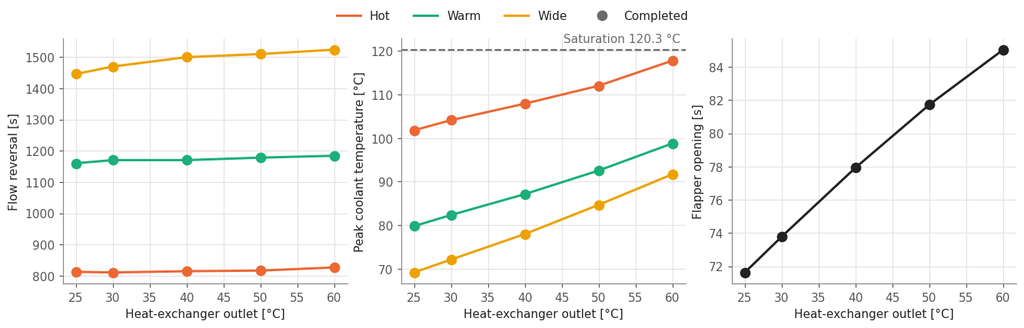

| label | status | t_open | t_rev_hot | t_rev_warm | t_rev_wide | peak_hot | margin | n_warnings | wall_s |
| --- | --- | --- | --- | --- | --- | --- | --- | --- | --- |
| hx_outlet=25.0 | completed | 71.6 | 812 | 1160 | 1446 | 101.8 | 18.5 | 0 | 32 |
| hx_outlet=30.0 | completed | 73.8 | 810 | 1170 | 1470 | 104.1 | 16.2 | 0 | 31 |
| hx_outlet=40.0 | completed | 77.9 | 814 | 1170 | 1500 | 107.9 | 12.4 | 0 | 32 |
| hx_outlet=50.0 | completed | 81.7 | 816 | 1178 | 1510 | 112.0 | 8.3 | 0 | 31 |
| hx_outlet=60.0 | completed | 85.0 | 826 | 1184 | 1524 | 117.8 | 2.5 | 0 | 33 |

```python
show("hx_outlet", "p_hx_outlet", "Heat-exchanger outlet [°C]")
```

## System pressure

Pressure moves the saturation line and little else: same opening time, reversals within 4 s. The margin goes from 4.9 °C at 1.5 bar to 32.9 °C at 4 bar.

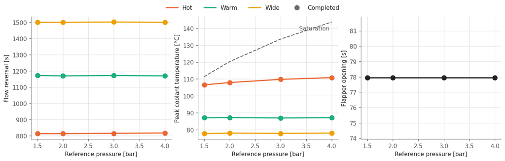

| label | status | t_open | t_rev_hot | t_rev_warm | t_rev_wide | peak_hot | margin | n_warnings | wall_s |
| --- | --- | --- | --- | --- | --- | --- | --- | --- | --- |
| p_ref=150000.0 | completed | 77.9 | 814 | 1172 | 1500 | 106.5 | 4.9 | 0 | 31 |
| p_ref=200000.0 | completed | 77.9 | 814 | 1170 | 1500 | 107.9 | 12.4 | 0 | 31 |
| p_ref=300000.0 | completed | 77.9 | 816 | 1172 | 1502 | 109.8 | 23.8 | 0 | 31 |
| p_ref=400000.0 | completed | 77.9 | 818 | 1170 | 1500 | 110.8 | 32.9 | 0 | 31 |

```python
show("pressure", "p_p_ref", "Reference pressure [bar]", scale=1e-5)
```

## Flapper threshold

The flapper opens when the loop flow drops to this fraction of its nominal value. At 0.1 it opens at about 235 s, the natural-circulation path arrives late and the hot channel creeps to saturation.

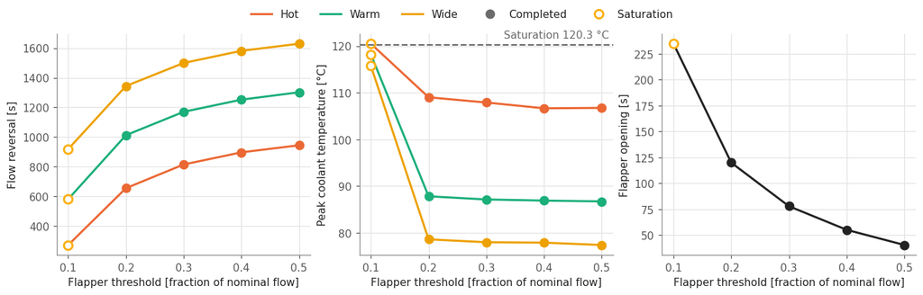

| label | status | t_open | t_rev_hot | t_rev_warm | t_rev_wide | peak_hot | margin | n_warnings | wall_s |
| --- | --- | --- | --- | --- | --- | --- | --- | --- | --- |
| flapper_fraction=0.1 | saturation | 234.7 | 270 | 580 | 918 | 120.5 | -0.2 | 0 | 29 |
| flapper_fraction=0.2 | completed | 120.0 | 654 | 1012 | 1344 | 109.0 | 11.3 | 0 | 28 |
| flapper_fraction=0.3 | completed | 77.9 | 814 | 1170 | 1500 | 107.9 | 12.4 | 0 | 32 |
| flapper_fraction=0.4 | completed | 55.2 | 896 | 1252 | 1582 | 106.7 | 13.6 | 0 | 37 |
| flapper_fraction=0.5 | completed | 40.5 | 944 | 1302 | 1630 | 106.8 | 13.5 | 0 | 39 |

```python
show("flapper_threshold", "p_flapper_fraction", "Flapper threshold [fraction of nominal flow]")
```

## Flapper area

The area does not change the opening time, only what follows. At 0.3 times the default the natural-circulation path is too restrictive and the hot channel saturates at about 1420 s (stops table).

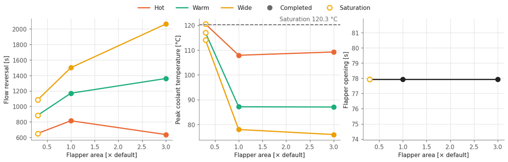

| label | status | t_open | t_rev_hot | t_rev_warm | t_rev_wide | peak_hot | margin | n_warnings | wall_s |
| --- | --- | --- | --- | --- | --- | --- | --- | --- | --- |
| flapper_area=0.3 | saturation | 77.9 | 650 | 884 | 1084 | 120.5 | -0.2 | 0 | 30 |
| flapper_area=1.0 | completed | 77.9 | 814 | 1170 | 1500 | 107.9 | 12.4 | 0 | 29 |
| flapper_area=3.0 | completed | 77.9 | 636 | 1360 | 2064 | 109.2 | 11.1 | 0 | 33 |

```python
show("flapper_area", "p_flapper_area", "Flapper area [× default]", scale=1e3)
```

## Friction law

Blasius under-predicts friction in the laminar natural-circulation regime, so the hot peak comes out lower, about 90 °C against 108 °C. The regime-dependent law, the default, is the physical one.

```python
table(load("friction"))
```

| label | status | t_open | t_rev_hot | t_rev_warm | t_rev_wide | peak_hot | margin | n_warnings | wall_s |
| --- | --- | --- | --- | --- | --- | --- | --- | --- | --- |
| friction=regime | completed | 77.9 | 814 | 1170 | 1500 | 107.9 | 12.4 | 0 | 28 |
| friction=blasius | completed | 84.0 | 1108 | 1680 | 1930 | 89.8 | 30.5 | 0 | 26 |

## Heat-transfer law

The regime-dependent heat-transfer law moves the peaks by about 1 °C. Its run records three NumPy RuntimeWarnings, printed below, and completes.

```python
table(load("htc"))
```

| label | status | t_open | t_rev_hot | t_rev_warm | t_rev_wide | peak_hot | margin | n_warnings | wall_s |
| --- | --- | --- | --- | --- | --- | --- | --- | --- | --- |
| htc=dittus | completed | 77.9 | 814 | 1170 | 1500 | 107.9 | 12.4 | 0 | 28 |
| htc=regime | completed | 77.9 | 806 | 1156 | 1486 | 107.0 | 13.3 | 3 | 30 |

```python
def warning_texts(axis, label):
    row = load(axis).set_index("label").loc[label]
    for text in dict.fromkeys(row["warnings"].split(" | ")):
        print(text)


warning_texts("htc", "htc=regime")
```

```
RuntimeWarning: invalid value encountered in subtract
```

## Solver tolerance

The absolute tolerance is `atol_rel` times each variable's own scale. At `atol_rel = 0.1`, 30 °C on a temperature, the run stops at 286 s with the hot peak at 66 °C, far from saturation; the error, printed below the figure, names the step failure. At 1e-2 the run completes but the hot reversal moves to about 1094 s against 814 s; at 1e-3 it is off by 8 s. From 1e-4 down the opening, reversals and peak agree within about 0.1 s, 2 s and 0.1 °C.

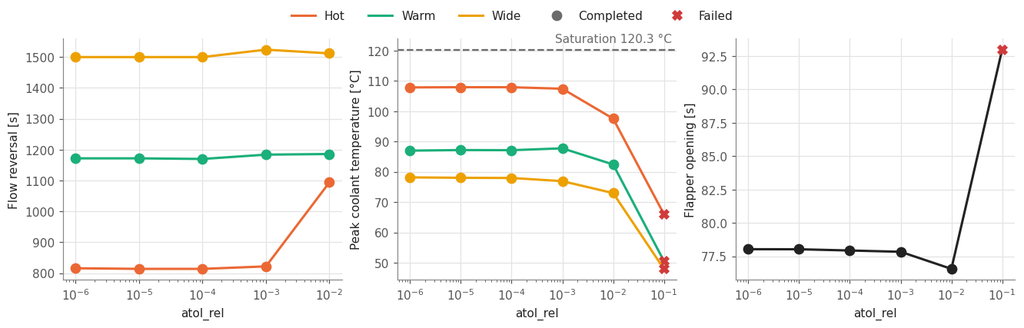

| label | status | t_open | t_rev_hot | t_rev_warm | t_rev_wide | peak_hot | margin | n_warnings | wall_s |
| --- | --- | --- | --- | --- | --- | --- | --- | --- | --- |
| atol=0.1,rtol=0.001 | failed | 93.0 |  |  |  | 66.1 | 54.2 | 0 | 11 |
| atol=0.01,rtol=0.001 | completed | 76.6 | 1094 | 1186 | 1512 | 97.6 | 22.7 | 0 | 21 |
| atol=0.001,rtol=0.0001 | completed | 77.8 | 822 | 1184 | 1524 | 107.4 | 12.9 | 0 | 26 |
| atol=0.0001,rtol=0.0001 | completed | 77.9 | 814 | 1170 | 1500 | 107.9 | 12.4 | 0 | 36 |
| atol=1e-05,rtol=1e-05 | completed | 78.0 | 814 | 1172 | 1500 | 107.9 | 12.4 | 0 | 105 |
| atol=1e-06,rtol=1e-06 | completed | 78.0 | 816 | 1172 | 1500 | 107.8 | 12.4 | 0 | 424 |

```python
show("tolerance", "atol_rel", "atol_rel", logx=True)
```

```python
failed = load("tolerance").query("status == 'failed'")
print(failed["label"].item())
print(failed["error"].item())
```

```
atol=0.1,rtol=0.001
TransientRuntimeError: At t = 286.00000: IDA IDA_CONV_FAIL(-4): Convergence test failures occurred too many times during one internal time step or minimum step size was reached. — the modified-Newton corrector could not converge and the step fell to hmin (a stiff transient, or a tolerance the integr…
```

## Trip time (pump trip and scram together)

This axis moves the pump trip and the scram together, from 1 to 30 s. The opening goes from about 76 s to 105 s and the reversals move by 26 to 28 s, so the opening stays about 75 s after the trip: the trip time shifts the start of the accident, nothing else. The width of the rod-insertion ramp, 0.1 to 5 s, moves the opening by under 3 s and the peaks by under 1 °C.

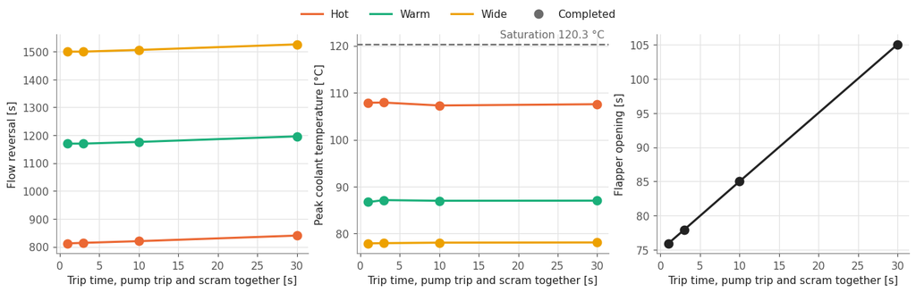

| label | status | t_open | t_rev_hot | t_rev_warm | t_rev_wide | peak_hot | margin | n_warnings | wall_s |
| --- | --- | --- | --- | --- | --- | --- | --- | --- | --- |
| t_scram=1.0 | completed | 75.9 | 812 | 1170 | 1500 | 107.9 | 12.4 | 0 | 42 |
| t_scram=3.0 | completed | 77.9 | 814 | 1170 | 1500 | 107.9 | 12.4 | 0 | 42 |
| t_scram=10.0 | completed | 85.0 | 820 | 1176 | 1506 | 107.3 | 13.0 | 0 | 43 |
| t_scram=30.0 | completed | 105.1 | 840 | 1196 | 1526 | 107.6 | 12.7 | 0 | 45 |

```python
show("scram", "p_t_scram", "Trip time, pump trip and scram together [s]",
     rows=lambda df: df["label"].str.startswith("t_scram"))
```

```python
table(load("scram").query("label.str.startswith('ramp_width')"))
```

| label | status | t_open | t_rev_hot | t_rev_warm | t_rev_wide | peak_hot | margin | n_warnings | wall_s |
| --- | --- | --- | --- | --- | --- | --- | --- | --- | --- |
| ramp_width=0.1 | completed | 77.7 | 814 | 1170 | 1500 | 107.9 | 12.4 | 0 | 43 |
| ramp_width=0.5 | completed | 77.9 | 814 | 1170 | 1500 | 107.9 | 12.4 | 0 | 42 |
| ramp_width=2.0 | completed | 78.9 | 814 | 1170 | 1500 | 107.4 | 12.9 | 0 | 44 |
| ramp_width=5.0 | completed | 80.3 | 818 | 1174 | 1504 | 107.3 | 13.0 | 0 | 41 |

## Initial guesses

The toolkit guess, the closed-form seed, a uniform ballpark, a hand-made expert guess and twenty random ±30 % perturbations of the toolkit guess, with entry residuals from 10.8 to 1.4e6. All 24 complete. Over the 24 rows the steady flows agree to about 1e-7 kg/s, the reversals within one 2 s output step and the warm and wide peaks within about 0.2 °C, the hot peak within 0.003 °C.

```python
guesses = load("guesses")
table(guesses, ["label", "residual_entry", "status", "t_open", "t_rev_hot", "peak_hot", "n_warnings"])
```

| label | residual_entry | status | t_open | t_rev_hot | peak_hot | n_warnings |
| --- | --- | --- | --- | --- | --- | --- |
| toolkit | 10.8 | completed | 77.9 | 814 | 107.9 | 0 |
| seed | 7.42e+04 | completed | 77.9 | 814 | 107.9 | 0 |
| ballpark | 1.38e+05 | completed | 77.9 | 814 | 107.9 | 0 |
| expert | 3.76e+04 | completed | 77.9 | 814 | 107.9 | 3 |
| perturbed-0 | 1.23e+06 | completed | 77.9 | 814 | 107.9 | 0 |
| perturbed-1 | 1.24e+06 | completed | 77.9 | 814 | 107.9 | 0 |
| perturbed-2 | 1.29e+06 | completed | 77.9 | 814 | 107.9 | 0 |
| perturbed-3 | 1.29e+06 | completed | 77.9 | 814 | 107.9 | 0 |
| perturbed-4 | 1.42e+06 | completed | 77.9 | 814 | 107.9 | 0 |
| perturbed-5 | 1.3e+06 | completed | 77.9 | 814 | 107.9 | 0 |
| perturbed-6 | 1.1e+06 | completed | 77.9 | 814 | 107.9 | 0 |
| perturbed-7 | 1.23e+06 | completed | 77.9 | 814 | 107.9 | 0 |
| perturbed-8 | 1.16e+06 | completed | 77.9 | 814 | 107.9 | 0 |
| perturbed-9 | 1.31e+06 | completed | 77.9 | 814 | 107.9 | 0 |
| perturbed-10 | 1.39e+06 | completed | 77.9 | 814 | 107.9 | 0 |
| perturbed-11 | 1.21e+06 | completed | 77.9 | 814 | 107.9 | 0 |
| perturbed-12 | 1.27e+06 | completed | 77.9 | 814 | 107.9 | 0 |
| perturbed-13 | 1.23e+06 | completed | 77.9 | 814 | 107.9 | 0 |
| perturbed-14 | 1.27e+06 | completed | 77.9 | 814 | 107.9 | 0 |
| perturbed-15 | 1.21e+06 | completed | 77.9 | 814 | 107.9 | 0 |
| perturbed-16 | 1.22e+06 | completed | 77.9 | 814 | 107.9 | 0 |
| perturbed-17 | 1.27e+06 | completed | 77.9 | 814 | 107.9 | 0 |
| perturbed-18 | 1.31e+06 | completed | 77.9 | 814 | 107.9 | 0 |
| perturbed-19 | 1.23e+06 | completed | 77.9 | 814 | 107.9 | 0 |

```python
columns = ["mdot_hot", "mdot_warm", "mdot_wide", "mdot_bypass", "mdot_pump", "t_open", "t_rev_hot", "t_rev_warm",
           "t_rev_wide", "peak_hot", "peak_warm", "peak_wide"]
spread = guesses[columns].agg(lambda c: c.max() - c.min())
print(spread.to_string(float_format="{:.2e}".format))
```

```
mdot_hot      4.32e-10
mdot_warm     7.44e-10
mdot_wide     5.25e-10
mdot_bypass   6.76e-08
mdot_pump     6.82e-08
t_open        4.81e-07
t_rev_hot     0.00e+00
t_rev_warm    2.00e+00
t_rev_wide    2.00e+00
peak_hot      2.11e-03
peak_warm     2.39e-01
peak_wide     2.10e-01
```

The expert guess records three warnings, one per heated channel, printed below. They are raised while the expert guess solves each heated plate alone with `symmetric_plate_steady_state`, a helper system with a fixed inlet temperature, not by the transient system. The toolkit guess on the same system records none, and the expert run completes.

```python
warning_texts("guesses", "expert")
```

```
UserWarning: HotChannel has a 'Tin' supplier but no 'Tin_minus' supplier; under reversed/natural-convection flow its advection falls back to the upstream temperature (Tin) instead of the downstream one, silently mis-advecting. Wire a 'Tin_minus' edge (in_series/flow_edge do this automatically) for a…
UserWarning: WarmChannel has a 'Tin' supplier but no 'Tin_minus' supplier; under reversed/natural-convection flow its advection falls back to the upstream temperature (Tin) instead of the downstream one, silently mis-advecting. Wire a 'Tin_minus' edge (in_series/flow_edge do this automatically) for …
UserWarning: WideChannel has a 'Tin' supplier but no 'Tin_minus' supplier; under reversed/natural-convection flow its advection falls back to the upstream temperature (Tin) instead of the downstream one, silently mis-advecting. Wire a 'Tin_minus' edge (in_series/flow_edge do this automatically) for …
```

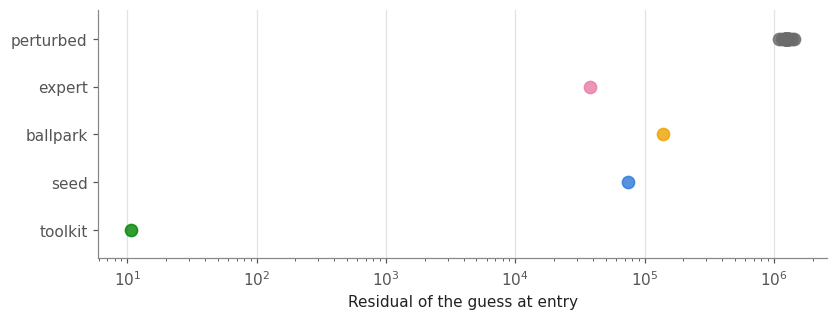

```python
kinds = ["toolkit", "seed", "ballpark", "expert", "perturbed"]
colors = dict(toolkit=plots.COLORS["pump"], seed=plots.COLORS["bypass"], ballpark=plots.COLORS["wide"],
              expert=plots.COLORS["flapper"], perturbed=plots.NEUTRAL)
with plots.style():
    fig, ax = plt.subplots(figsize=(7.5, 2.8), layout="constrained")
    for i, kind in enumerate(kinds):
        r = guesses[guesses["guess_kind"] == kind]["residual_entry"]
        ax.plot(r, np.full(len(r), i), linestyle="none", marker="o", color=colors[kind], alpha=0.8)
    ax.set_xscale("log")
    ax.set_yticks(range(len(kinds)), kinds)
    ax.set_ylim(-0.6, len(kinds) - 0.4)
    ax.grid(False, axis="y")
    ax.set_xlabel("Residual of the guess at entry")
    plt.show()
```

## Output grid

The output grid is where the solution is reported, not where IDA steps, and the flapper opening does not depend on it.

```python
grid = load("grid")
print(grid[["label", "t_open"]].to_string(index=False, float_format="{:.6f}".format))
table(grid)
```

```
 label    t_open
 n=626 77.935437
n=1251 77.935437
n=2501 77.935437
```

| label | status | t_open | t_rev_hot | t_rev_warm | t_rev_wide | peak_hot | margin | n_warnings | wall_s |
| --- | --- | --- | --- | --- | --- | --- | --- | --- | --- |
| n=626 | completed | 77.9 | 816 | 1172 | 1504 | 107.3 | 13.0 | 0 | 30 |
| n=1251 | completed | 77.9 | 814 | 1170 | 1500 | 107.9 | 12.4 | 0 | 30 |
| n=2501 | completed | 77.9 | 814 | 1170 | 1499 | 107.9 | 12.4 | 0 | 30 |

## Summary

```python
counts = sweeps.summary(load(axis) for axis in sweeps.AXES)
counts.loc[len(counts)] = ["all", *counts.iloc[:, 1:].sum()]
counts.style.hide(axis="index")
```

| axis | cases | completed | saturation | failed | timeout |
| --- | --- | --- | --- | --- | --- |
| flapper_area | 3 | 2 | 1 | 0 | 0 |
| flapper_threshold | 5 | 4 | 1 | 0 | 0 |
| friction | 2 | 2 | 0 | 0 | 0 |
| gaps | 7 | 5 | 2 | 0 | 0 |
| grid | 3 | 3 | 0 | 0 | 0 |
| guesses | 24 | 24 | 0 | 0 | 0 |
| htc | 2 | 2 | 0 | 0 | 0 |
| hx_outlet | 5 | 5 | 0 | 0 | 0 |
| inertia | 5 | 3 | 2 | 0 | 0 |
| power | 15 | 13 | 2 | 0 | 0 |
| pressure | 4 | 4 | 0 | 0 | 0 |
| pump_head | 5 | 5 | 0 | 0 | 0 |
| scram | 8 | 8 | 0 | 0 | 0 |
| tolerance | 6 | 5 | 0 | 1 | 0 |
| all | 94 | 85 | 8 | 1 | 0 |

94 cases ran and 85 completed. The 8 saturation stops sit at the edges of the envelope: power from 0.95, a short coastdown, a narrow hot channel or bypass, a late or small flapper. Each is the hot channel saturating for a physical reason, with the channel and cell named in its error (stops table).

The one failure is the loosest tolerance, which stops at 286 s with the hot peak at 66 °C, far from saturation, and an error naming the step failure. No failure is unexplained, and the default path runs without a warning.